# MB250 Microarray Data - Rspondin KO/KI without infection in stomach corpus - Reanalysis with LIMMA

# Introduction

This is data from a stomach corpus samples of mouse experiments (Rspo KI, no infection) hybridized as dual channel libraries to Agilent 014568 micro arrays.

## Data overview

### Samples

|  | Chip.Barcode | Cy3_label | Cy5_label | dye_swap |
| --- | --- | --- | --- | --- |
| US22502595_251486828513_S01_GE2_1105_Oct12_1_3 | 251486828513_1_3 | Rspo KI_14d NI_9494 | WT_14d NI_9481 | TRUE |
| US22502595_251486828513_S01_GE2_1105_Oct12_1_4 | 251486828513_1_4 | WT_14d NI_9479 | Rspo KI_14d NI_9495 | FALSE |

## Raw data

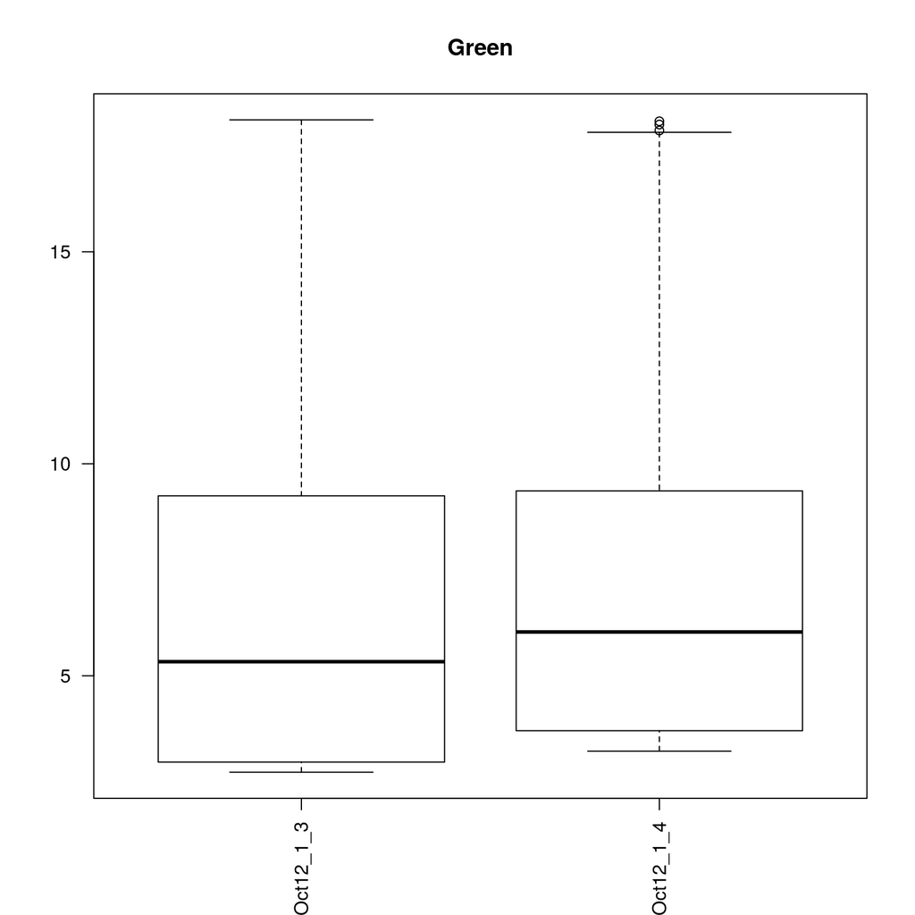

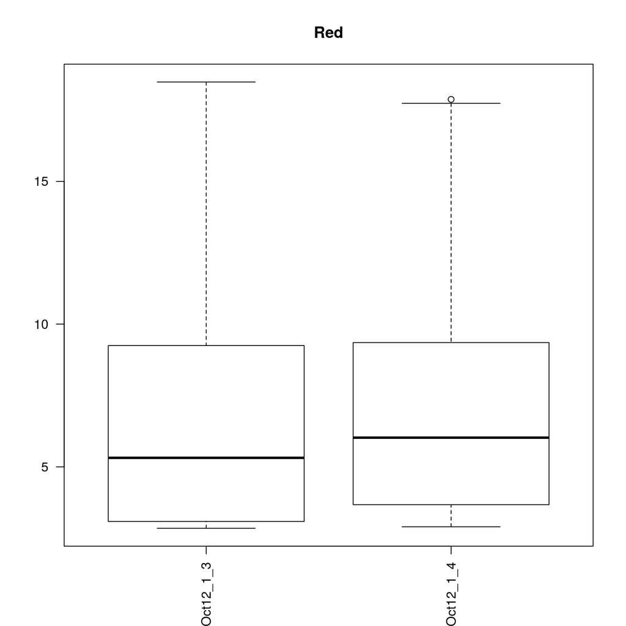

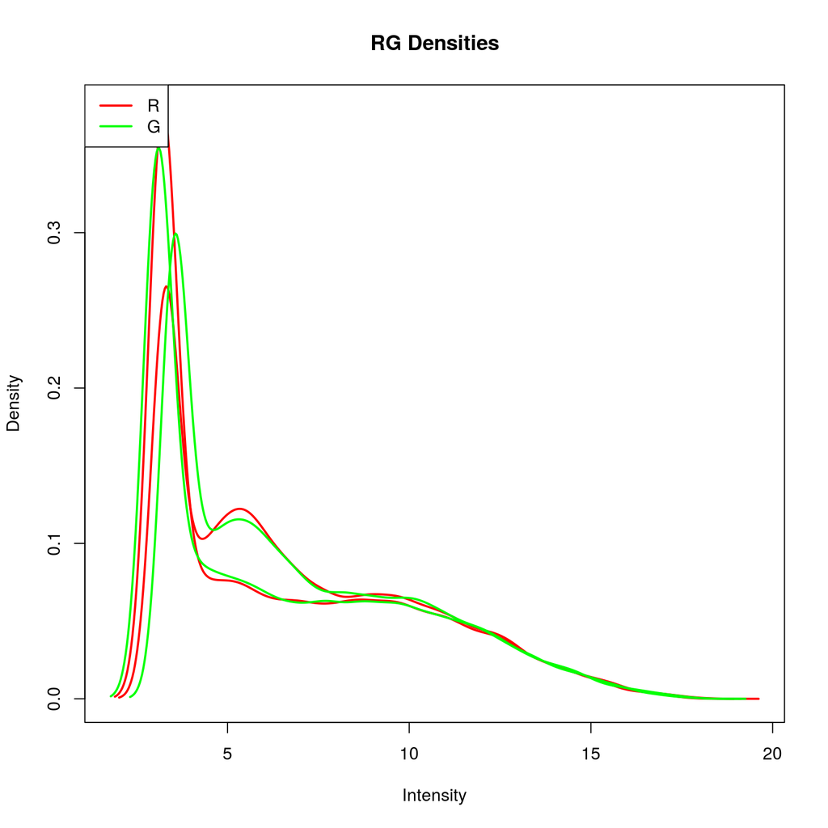

# Within-array normalization

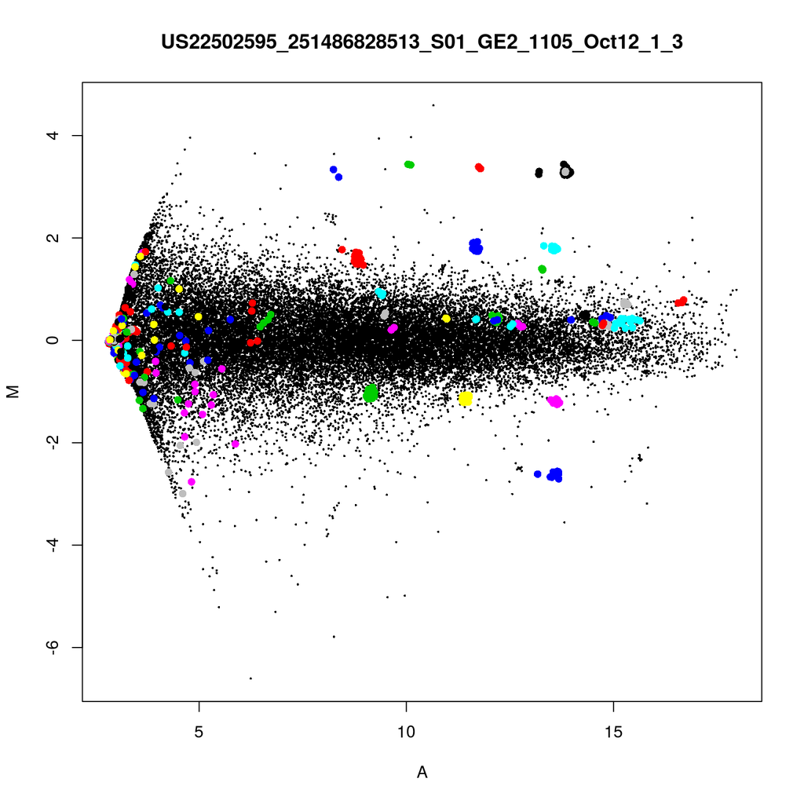

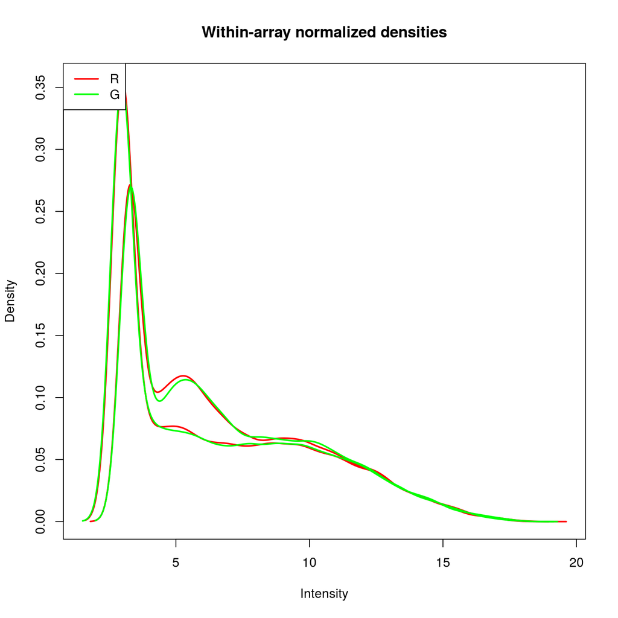

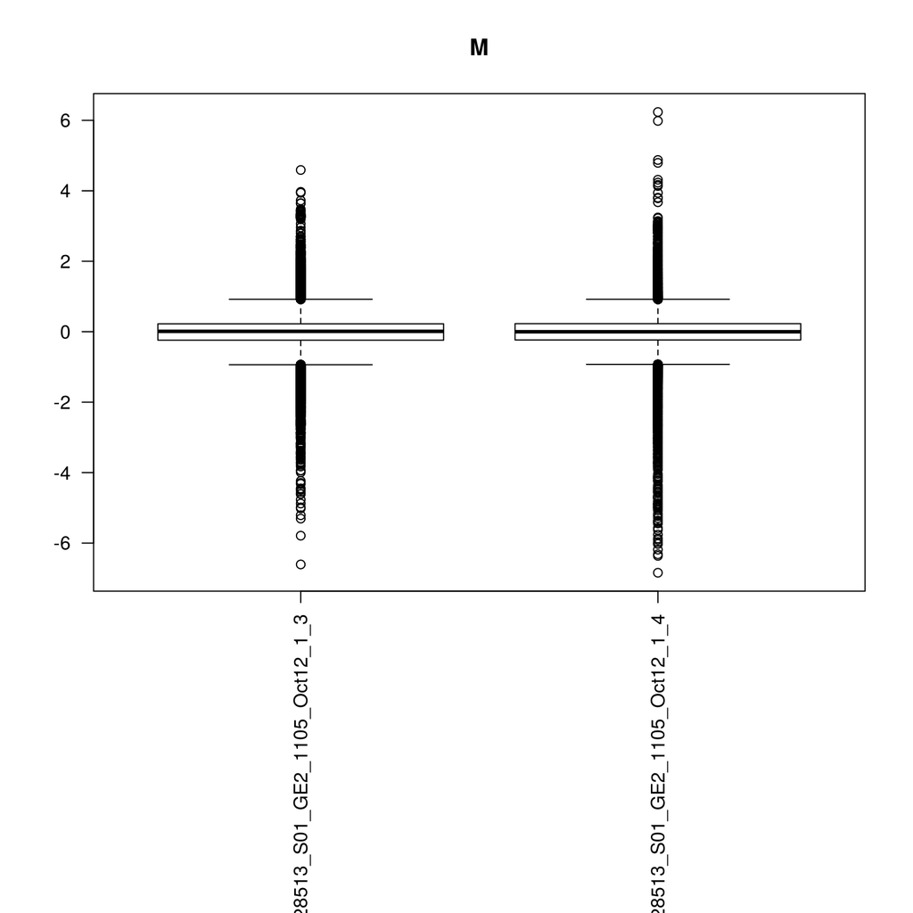

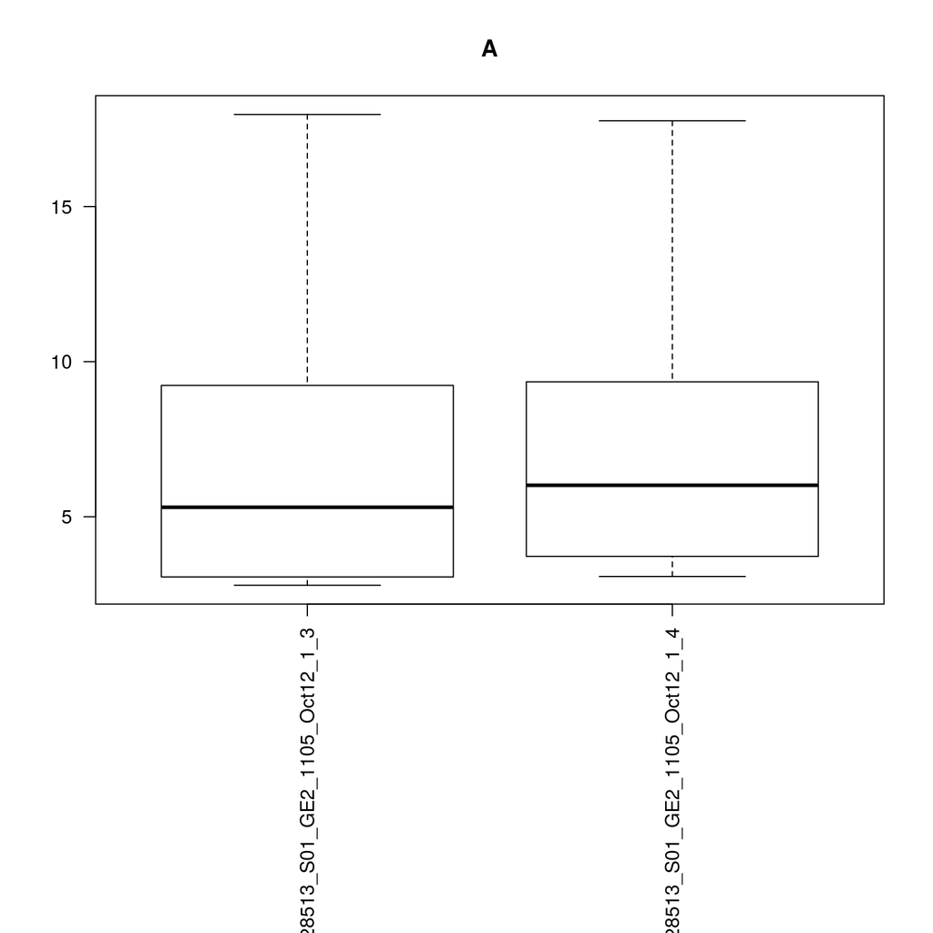

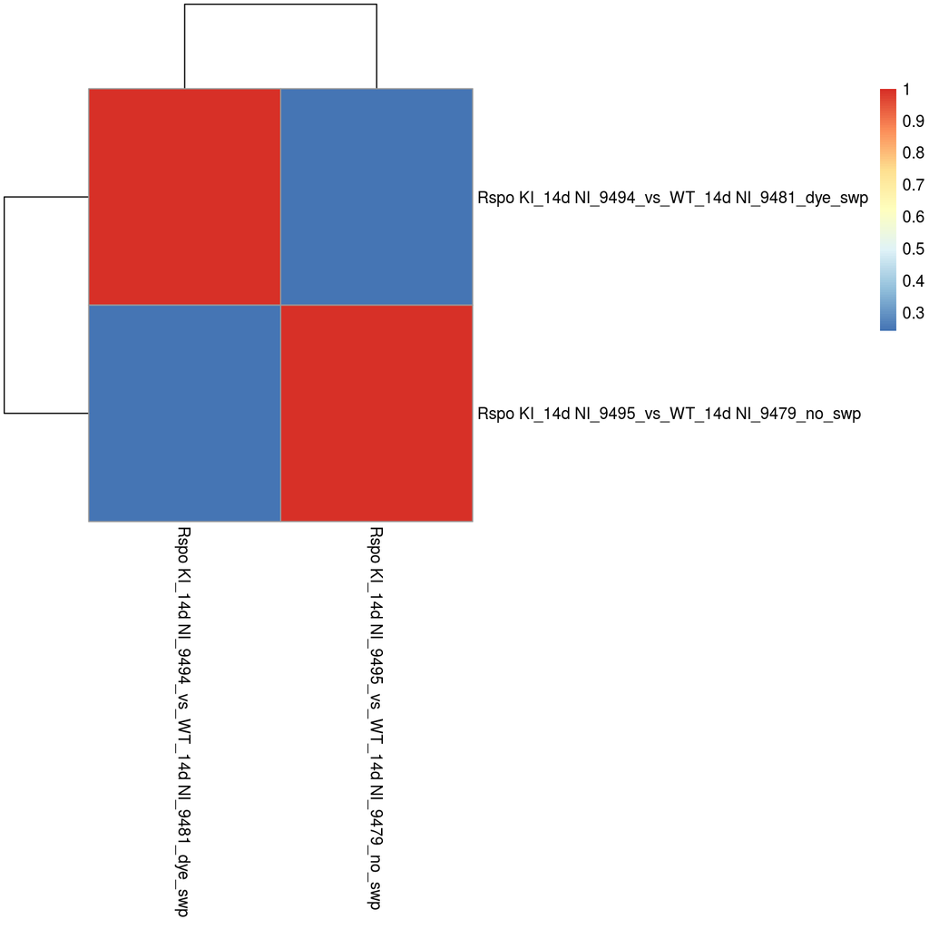

# Rspondin expression in samples

M-value is the difference between two conditions (R minus G channels or G minus R, depending on dye swap ) for a probe.

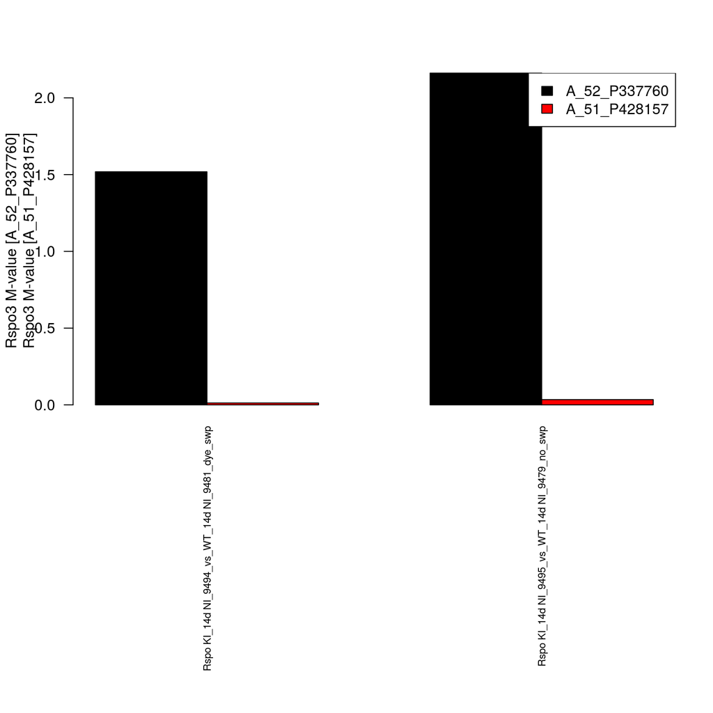

Rspondin3 mRNA expression is higher in all Rspo KI samples as expected. Probe A_51_P428157, which shows no expression maps with mismatches to an 3’UTR not present in any of the currently accepted transript isoforms.

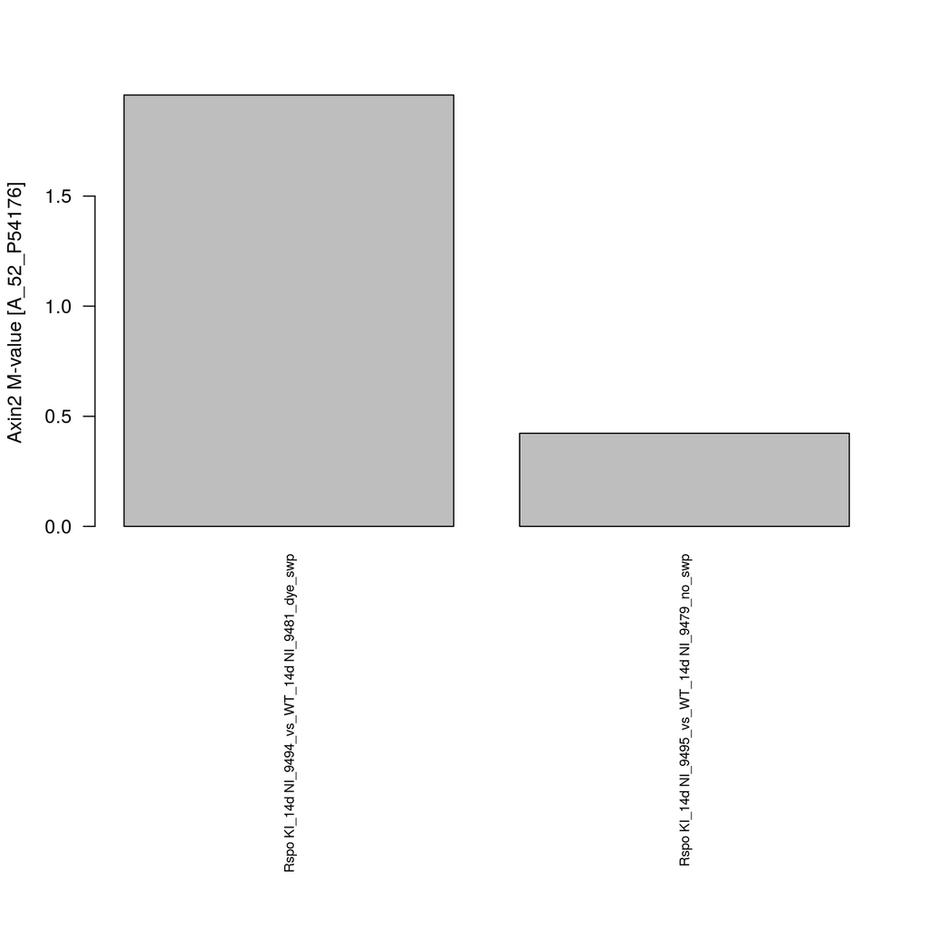

# Between array normalization using Aquantile

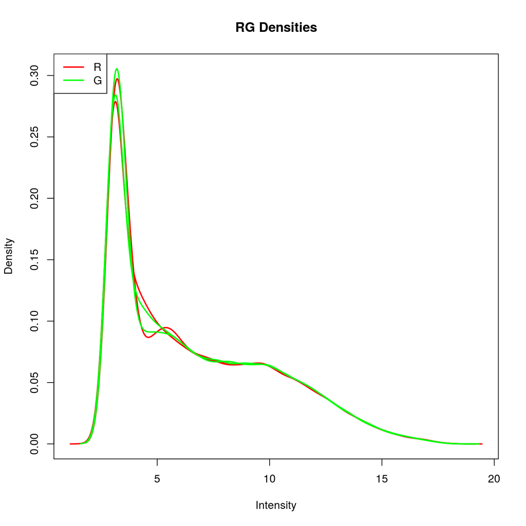

## Control probes

The following control probes exist on the arrays used in this experiment:

- Corner associated (used for orientation purposes during scanning)
- Bright corner
- Dark corner
- Negative controls
- 3xSLv1 (hairpin probe that does not hybridize well with any possible RNA)
- Positive controls
- Human GAPDH and PGK1 probes
- Deletion stringency probes (DCP, probe with varying number of insertions/changes with respect to reference; the number after the “_" denotes the number of differences to the reference which should correlate with lower expression)
- E1A_r60: spike-in probes with concentrations that should cover the whole dynamic range of the array

There are a few other expression probes that are used by Agilent’s feature extraction/QC pipeline.

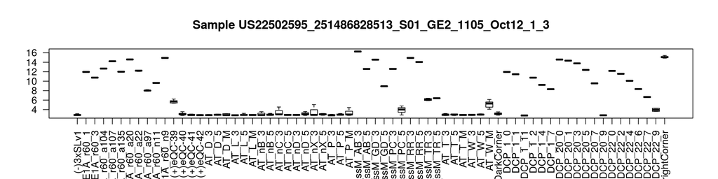

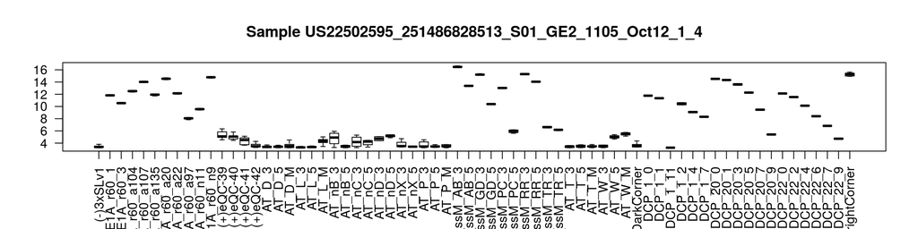

```r
ed=ed_orig
save(ed, RG, MA, MA.n, file="../Data/Processed/MB250_Corpus_Rspo_KI_and_KO_with_or_wo_Hp_micro_array_preprocessed_data.Rdata")
```